Jonathan Hobbs

# Chances of sustaining a new exercise regime and the effect of the first month

Technogym's mywellness system is a platform for (among other features) tracking exercise. All exercise in and outside of the gym, as well as daily movement, can be recorded either manually using the app or website or automatically using the TGS key or connected devices. All of this exercise is converted into MOVEs, which are a standardised points system.

Although the mywellness system is optional, continuous recording of MOVEs is an indicator of whether members are sustaining their exercise regime or not. It is possible that members will drop off of the mywellness system but continue to exercise and conversely that members stop exercising meaningfully in the gym but continue to automatically record MOVEs from movement tracking. Despite these caveats it is an insightful proxy measure for whether members are continuing to exercise or not.

This analysis will focus on the effect of the total MOVEs and number of days recorded in the first month of use. The idea is to establish a helpful target for new members who want to establish and maintain a regular training regime.

## Preparing the data

```python
#Import libraries
import pandas as pd
import numpy as np
import matplotlib.pyplot as plt
from scipy.stats import ttest_ind
from statsmodels.stats.multicomp import pairwise_tukeyhsd
from sklearn.linear_model import LinearRegression, LogisticRegression
from sklearn.model_selection import train_test_split
from sklearn.neighbors import KNeighborsClassifier
from sklearn.naive_bayes import GaussianNB
```

Having imported various libraries that will be used, the first step is to import the data. This is in the form of 'reports' generated in mywellness for each month from May 2018 to April 2019 inclusive.

```python
#Read data to dataframes
months = ['may2018', 'june2018', 'july2018', 'august2018', 'september2018', 'october2018', 'november2018', 'december2018', 'january2019', 'february2019', 'march2019', 'april2019']
data = {}
for m in months:
    df = pd.read_csv(m + '.csv')
    moves = df[['Cloud Id', 'Total MOVEs (MOVEs)', 'Training days']].rename(columns = {'Cloud Id':'id', 'Total MOVEs (MOVEs)': 'total', 'Training days':'days'})
    data[m] = moves

#Merge data
all_users = data['may2018'].merge(data['june2018'], on='id', suffixes=('_may', '_jun')).merge(data['july2018'], on='id', suffixes=(False, False)).merge(data['august2018'], on='id', suffixes=('_jul', '_aug')).merge(data['september2018'], on='id', suffixes=(False, False)).merge(data['october2018'], on='id', suffixes=('_sep', '_oct')).merge(data['november2018'], on='id', suffixes=(False, False)).merge(data['december2018'], on='id', suffixes=('_nov', '_dec')).merge(data['january2019'], on='id', suffixes=(False, False)).merge(data['february2019'], on='id', suffixes=('_jan', '_feb')).merge(data['march2019'], on='id', suffixes=(False, False)).merge(data['april2019'], on='id', suffixes=('_mar', '_apr'))
#print(all_users.head())
```

It is then necessary to create several new columns.

1. Establishing the 'first' month. For this purpose, the 'first' month is defined as a month in which MOVEs are recorded after not recording any in the previous month. This does mean that some rows will be counted multiple times if MOVEs are recorded in non-consecutive months. Effectively, each is counted as a fresh start, and a separate trial for this analysis.

```python
#Select new users and add a column for when they first recorded MOVEs
mon = ['_may', '_jun', '_jul', '_aug', '_sep', '_oct', '_nov', '_dec', '_jan', '_feb', '_mar', '_apr']
new_users = pd.DataFrame({})
for i in range(1, len(mon) - 2):
    m = mon[i]
    n = mon[i-1]
    df = all_users[(all_users['total'+n] == 0) & (all_users['total'+m] > 0)]
    df = df.assign(new=m)
    new_users = new_users.append(df).reset_index(drop=True)
```

1. Finding how long they continued recording MOVEs. Because of the issue above with some members being counted several times, it is not appropriate to simply count the total number of months recorded. The solution is to determine which column to start counting using the index position of the value in 'new' and then to search forwards. The loop simply breaks if the search finds a 0.

(Two columns are created - one showing the number of months and one showing '0' for less than 3 months or '1' for 3 or more. The reason for selecting 3 months as the threshold is described below.)

```python
def continuation1(row):
    cont = 0
    start = mon.index(row['new'])
    for i in range(start, len(mon)):
        mn = mon[i]
        if row['total' + mn] > 0:
            cont += 1
        else:
            break
    return cont
conts = new_users.apply(lambda row: continuation1(row), axis=1)
new_users = new_users.assign(continuation=conts)
conts2 = pd.cut(new_users.continuation, [0, 2, 12], labels=[0, 1])
new_users = new_users.assign(cont_group=conts2.astype(int))
```

1. Finding the total MOVEs and number of days recorded in the first month.

```python
total_first = new_users.apply(lambda row: row['total' + row.new], axis=1)
new_users = new_users.assign(total_first=total_first)
days_first = new_users.apply(lambda row: row['days' + row.new], axis=1)
new_users = new_users.assign(days_first=days_first)
```

## Looking at the data

Before going on to analyse this data, it is useful to look at various aspects.

```python
print("New users for each month.")
print(new_users.groupby('new').id.count())
print("Number of users continuing for each number of months.")
print(new_users.groupby('continuation').id.count())
print("Number of users continuing for either less than 3 months (0) or 3 or more (1).")
print(new_users.groupby('cont_group').id.count())
#print(new_users.groupby(['new', 'continuation']).id.count())
```

```
New users for each month.
new
_aug    56
_dec    28
_feb    26
_jan    79
_jul    38
_jun    37
_nov    45
_oct    45
_sep    45
Name: id, dtype: int64
Number of users continuing for each number of months.
continuation
1     153
2      85
3      41
4      40
5      23
6      21
7      11
8       9
9       6
10      6
11      4
Name: id, dtype: int64
Number of users continuing for either less than 3 months (0) or 3 or more (1).
cont_group
0    238
1    161
Name: id, dtype: int64
```

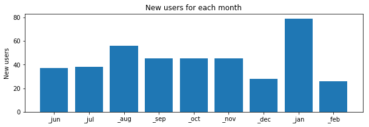

```python
new_monthly = new_users.groupby('new').id.count().reindex(mon).dropna().tolist()
#print(new_monthly)
plt.figure(figsize=(10, 3))
ax1 = plt.subplot()
plt.bar(range(len(new_monthly)), new_monthly)
ax1.set_xticks(range(len(new_monthly)))
ax1.set_xticklabels(mon[1:11])
plt.ylabel("New users")
plt.title("New users for each month")
plt.savefig('monthly_new_users.png')
```

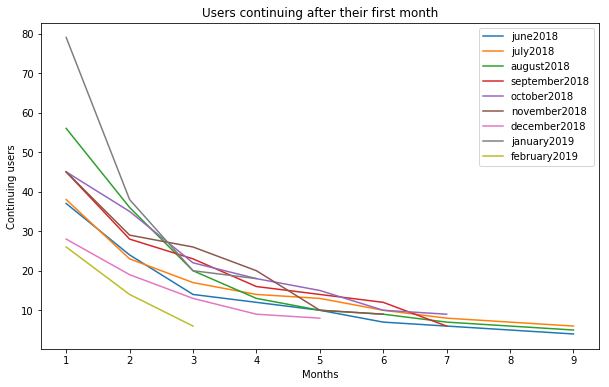

```python
conts_monthly = {}
for i in range(1, 10):
    m = mon[i]
    conts_monthly[m] = new_users[new_users.new == m].groupby('continuation').id.count().tolist()
    for c in conts_monthly[m]:
        break
    #plt.plot(range(len(conts_monthly[m])), conts_monthly[m])
    #plt.legend(months[1:10])

plt.figure(figsize=(10, 6))
ax2 = plt.subplot()
for i in range(1, 10):
    cumt = [new_monthly[(i-1)]]
    m = mon[i]
    #print(m)
    for c in range(len(conts_monthly[m])-1):
        drop = sum(conts_monthly[m][:(c+1)])
        cumt.append(new_monthly[(i-1)]-drop)
    #print(cumt)
    plt.plot(range(len(cumt)), cumt)
plt.legend(months[1:10])
plt.ylabel("Continuing users")
plt.xlabel("Months")
plt.title("Users continuing after their first month")
ax2.set_xticklabels(range(0, 10))
plt.savefig('continuing_users.png')
plt.show()
```

From looking at the graph of users continuing after their first month, it appears that there is a high drop-off in the first 3 months. After the third month, the number of users declines much more slowly. Therefore, 3 months appears to be a good threshold when categorising 'continuing' or 'non-continuing' users.

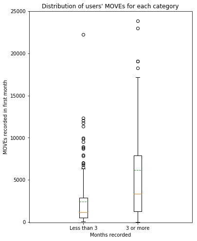

```python
c0_first = new_users[new_users.cont_group==0]['total_first'].tolist()
c1_first = new_users[new_users.cont_group==1]['total_first'].tolist()

conts_list = conts2.tolist()
plt.figure()
fig3, ax3 = plt.subplots()
fig3.set_size_inches(6, 8)
ax3.boxplot([c0_first, c1_first], showmeans=True, meanline=True)
ax3.axis([0,3,-50, 25000])
ax3.set_xticklabels(["Less than 3", "3 or more"])
plt.xlabel("Months recorded")
plt.ylabel("MOVEs recorded in first month")
plt.title("Distribution of users' MOVEs for each category")
plt.savefig('moves_box_plot.png')
```

```python
print(min(new_users.total_first))
print(max(new_users.total_first))
```

```
22
73745
```

Because of the very wide range of MOVEs recorded (22 to 73,745), it is more useful to look at this feature in terms of percentiles.

```python
centiles = pd.qcut(new_users.total_first, 100, labels=range(100))
new_users = new_users.assign(centile=centiles.astype(int))
#print(new_users.head())
```

```python
centile_pivot = new_users.groupby(['centile', 'cont_group']).id.count().reset_index().pivot(columns='cont_group', index='centile', values='id')
#print(centile_pivot)
days_pivot = new_users.groupby(['days_first', 'cont_group']).id.count().reset_index().pivot(columns='cont_group', index='days_first', values='id')
#print(days_pivot)
```

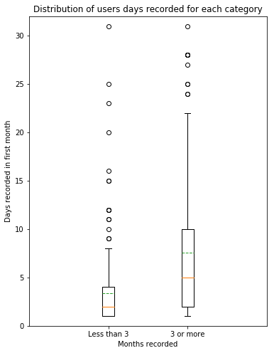

```python
c0_first_days = new_users[new_users.cont_group==0]['days_first'].tolist()
c1_first_days = new_users[new_users.cont_group==1]['days_first'].tolist()

plt.figure()
fig4, ax4 = plt.subplots()
fig4.set_size_inches(6, 8)
ax4.boxplot([c0_first_days, c1_first_days], showmeans=True, meanline=True)
ax4.axis([0,3, 0,32])
ax4.set_xticklabels(["Less than 3", "3 or more"])
plt.xlabel("Months recorded")
plt.ylabel("Days recorded in first month")
plt.title("Distribution of users days recorded for each category")
plt.savefig('days_box_plot.png')
```

From the box-plot graphs showing distributions for each category, they appear to be distinct groups. Using a 2-sample t-test for each variable, it can be shown with a very high probability that they are in fact significantly different. In terms of both total MOVEs and days recorded, we can be more than 99.999999% sure they are significantly different.

```python
tstat1, pval1 = ttest_ind(c0_first, c1_first)
print(pval1)
tstat2, pval2 = ttest_ind(c0_first_days, c1_first_days)
print(pval2)
```

```
9.613369076383727e-09
1.112641404713961e-12
```

Looking at the distribution of users' MOVEs and days recorded shows that both categories are widely spread and overlap substantially. However, it is noticeable that 'non-continuing' users are more concentrated in the bottom left - fewer MOVEs and fewer days - and there are more 'continuing' users in the top right - more MOVEs and more days. This also shows a positive correlation between MOVEs and days, which makes sense.

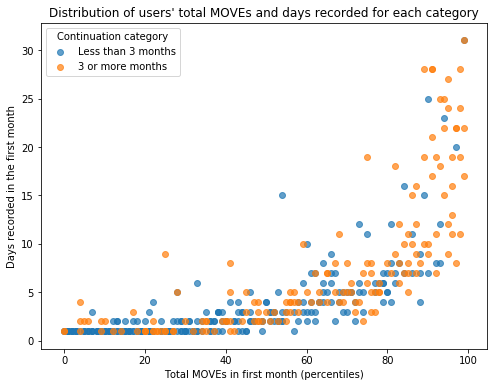

```python
plt.figure(figsize=(8,6))
plt.scatter(c0_moves_days['centile'], c0_moves_days['days_first'], alpha=0.7)
plt.scatter(c1_moves_days['centile'], c1_moves_days['days_first'], alpha=0.7)
plt.savefig('moves_days_scatter.png')
plt.xlabel("Total MOVEs in first month (percentiles)")
plt.ylabel("Days recorded in the first month")
plt.legend(["Less than 3 months", "3 or more months"], title="Continuation category")
plt.title("Distribution of users' total MOVEs and days recorded for each category")
```

## Using the data to train models

Using logistic regressions, it is possible to see the effects that total MOVEs and days recorded have on the probability of continuing for 3 or more months.

```
[[2.23373514]] [-1.53570855]
0.6766917293233082
[[3.04722879]] [-0.89024428]
0.6691729323308271
```

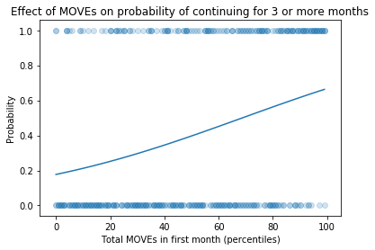

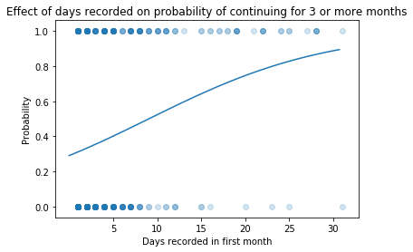

```python
centiles_norm = np.array([c*0.01 for c in centiles]).reshape(-1,1)
days_norm = np.array([d/31.0 for d in days_first]).reshape(-1,1)
regr3 = LogisticRegression(solver='lbfgs')
regr3.fit(centiles_norm, conts_list)
print(regr3.coef_, regr3.intercept_)
print(regr3.score(centiles_norm, conts_list))
y_3 = regr3.predict_proba(np.array([i*0.01 for i in range(100)]).reshape(-1, 1))
#print(y_3)
plt.figure()
ax5 = plt.subplot()
plt.plot([i*0.01 for i in range(100)], y_3[:,1])
plt.scatter(centiles_norm, conts_list, alpha=0.2)
ax5.set_xticks([0.0, .2, .4, .6, .8, 1.])
ax5.set_xticklabels([0, 20, 40, 60, 80, 100])
plt.xlabel("Total MOVEs in first month (percentiles)")
plt.ylabel("Probability")
plt.title("Effect of MOVEs on probability of continuing for 3 or more months")

regr4 = LogisticRegression(solver='lbfgs')
regr4.fit(days_norm, conts_list)
print(regr4.coef_, regr4.intercept_)
print(regr4.score(days_norm, conts_list))
y_4 = regr4.predict_proba(np.array([i*0.01 for i in range(100)]).reshape(-1, 1))
#print(y_3)
plt.figure()
ax6 = plt.subplot()
plt.plot([i*0.01 for i in range(100)], y_4[:,1])
plt.scatter(days_norm, conts_list, alpha=0.2)
ax6.set_xticks([5/31, 10/31, 15/31, 20/31, 25/31, 30/31])
ax6.set_xticklabels([5, 10, 15, 20, 25, 30])
plt.xlabel("Days recorded in first month")
plt.ylabel("Probability")
plt.title("Effect of days recorded on probability of continuing for 3 or more months")
```

Taking each variable independently, the logistic regressions have R-squared values of 0.677 for MOVEs and 0.669 for days recorded. However, it would also be interesting to train models using both variables together. This time, the data will be split so that the same data is not used for training and testing the model.

```python
c0_moves_days = new_users[new_users.cont_group == 0][['centile', 'days_first']]
c1_moves_days = new_users[new_users.cont_group == 1][['centile', 'days_first']]
moves_days = pd.concat([c0_moves_days, c1_moves_days])
#print(moves_days)
labels = len(c0_moves_days)*[0] + len(c1_moves_days)*[1]
m_d_train, m_d_test, labels_train, labels_test = train_test_split(moves_days, labels, test_size=0.8, random_state=401)
```

First, a multiple logistic regression. This gives an R-squared value of 0.391, which is disappointing compared to the single logistic regressions.

```python
c0_norm = c0_moves_days / c0_moves_days.max(axis=0)
c1_norm = c1_moves_days / c1_moves_days.max(axis=0)
m_d_norm = pd.concat([c0_norm, c1_norm])
m_d_train2, m_d_test2, labels_train2, labels_test2 = train_test_split(m_d_norm, labels, test_size=0.8, random_state=401)
multi_regr2 = LogisticRegression(solver='lbfgs')
multi_regr2.fit(m_d_train2, labels_train2)
print(multi_regr2.coef_)
print(multi_regr2.intercept_)
print(multi_regr2.score(m_d_test, labels_test))
```

```
[[0.95092612 0.90410146]]
[-0.8076982]
0.390625
```

Next, a K-Nearest Neighbours classifier. The best R-squared value for this is 0.678 with k=34.

```python
k_values = {}
for i in range(1, 80):
    classifier = KNeighborsClassifier(i)
    classifier.fit(m_d_train, labels_train)
    k_values[i] = classifier.score(m_d_test, labels_test)
best_k = max(k_values, key=k_values.get)
print(max(k_values, key=k_values.get), max(k_values.values()))
k_classifier = KNeighborsClassifier(best_k)
k_classifier.fit(m_d_train, labels_train)
```

```
34 0.678125
```

```
KNeighborsClassifier(algorithm='auto', leaf_size=30, metric='minkowski',
                     metric_params=None, n_jobs=None, n_neighbors=34, p=2,
                     weights='uniform')
```

Finally, a Naive Bayes classifier. This gives an R-squared value of 0.675.

```python
nb_classifier = GaussianNB()
nb_classifier.fit(m_d_train, labels_train)
print(nb_classifier.score(m_d_test, labels_test))
print(nb_classifier.theta_)
print(nb_classifier.sigma_ ** 0.5)
```

```
0.675
[[42.04651163  3.34883721]
 [58.69444444  7.41666667]]
[[23.78288764  4.65499851]
 [31.95206432  8.31790243]]
```

## Finding a goal

The last step is to use these models to find a combination of MOVEs and days recorded that will give new users a good chance of continuing. It is difficult to know what a 'good' chance is, so 50% will be calculated initially.

To get an idea, each model will be graphed. Each line takes a given number of days and plots the probability of continuing against the percentiles of MOVEs.

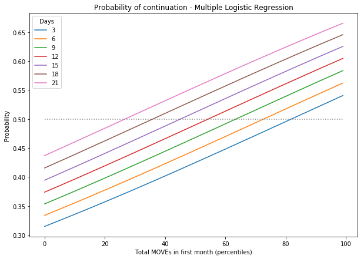

```python
days_goals3 = [r/31.0 for r in range(1,22,3)]
centiles_goals3 = [r*0.01 for r in range(100)]
plt.figure(figsize=(10,7))
ax7 = plt.subplot()
for d in days_goals3:
    prob_true = []
    for c in centiles_goals3:
        prob_true.append(multi_regr2.predict_proba([[c, d]])[0,1])
    #print(prob_true)
    plt.plot(centiles_goals3, prob_true)
plt.plot(centiles_goals3, (len(centiles_goals3)*[0.5]), linestyle=':', color='gray')
plt.legend(days_goal_labels, title="Days")
ax7.set_xticks([0.0, .2, .4, .6, .8, 1.])
ax7.set_xticklabels([0, 20, 40, 60, 80, 100])
plt.xlabel("Total MOVEs in first month (percentiles)")
plt.ylabel("Probability")
plt.title("Probability of continuation - Multiple Logistic Regression")
```

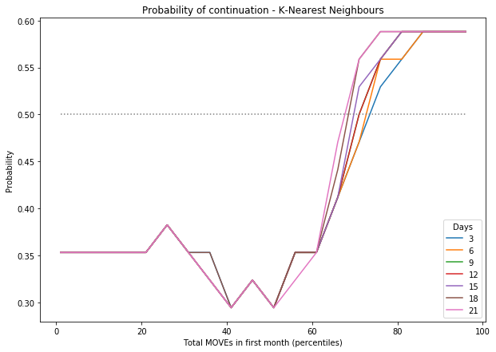

```python
plt.figure(figsize=(10,7))
centiles_goals = range(1, 101, 5)
days_goals = range(3, 22, 3)
days_goal_labels = []
for d in days_goals:
    days_goal_labels.append(d)
    prob_true = []
    for c in centiles_goals:
        prob_true.append(k_classifier.predict_proba([[c, d]])[0,1])
    #print(prob_true)
    plt.plot(centiles_goals, prob_true)
plt.plot(centiles_goals, (len(centiles_goals)*[0.5]), linestyle=':', color='gray')
plt.legend(days_goal_labels, title="Days")
plt.xlabel("Total MOVEs in first month (percentiles)")
plt.ylabel("Probability")
plt.title("Probability of continuation - K-Nearest Neighbours")
plt.savefig('k_neighbours.png')
```

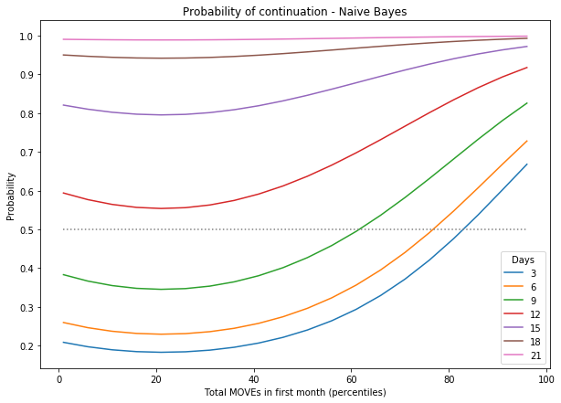

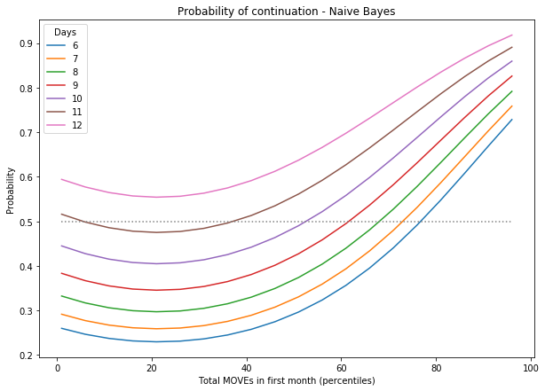

```python
plt.figure(figsize=(10,7))
for d in days_goals:
    prob_true = []
    for c in centiles_goals:
        prob_true.append(nb_classifier.predict_proba([[c, d]])[0,1])
    #print(prob_true)
    plt.plot(centiles_goals, prob_true)
plt.plot(centiles_goals, (len(centiles_goals)*[0.5]), linestyle=':', color='gray')
plt.legend(days_goal_labels, title="Days")
plt.xlabel("Total MOVEs in first month (percentiles)")
plt.ylabel("Probability")
plt.title("Probability of continuation - Naive Bayes")
plt.savefig('naive_bayes.png')

days_goals2 = range(6,13)
plt.figure(figsize=(10,7))
for d in days_goals2:
    prob_true = []
    for c in centiles_goals:
        prob_true.append(nb_classifier.predict_proba([[c, d]])[0,1])
    #print(prob_true)
    plt.plot(centiles_goals, prob_true)
plt.plot(centiles_goals, (len(centiles_goals)*[0.5]), linestyle=':', color='gray')
plt.legend(days_goals2, title="Days")
plt.xlabel("Total MOVEs in first month (percentiles)")
plt.ylabel("Probability")
plt.title("Probability of continuation - Naive Bayes")
plt.savefig('naive_bayes2.png')
```

The graphs reveal some interesting results. Firstly, the mutliple logistic regression model is based on a linear and unrealistic trade-off between MOVEs and days. Given its low R-squared score, it should be dismissed.

Next, the K-Nearest Neighbours model is heavily dependent on MOVEs. Due to the nature of the algorithm it is fairly rigid, though there are some unpredictable aspects, such as the 'W' shape between 30% and 60%.

The final question that arises is which pair of MOVEs and days to select. The loop below shows a list of possible combinations that give a probability of approximately 50% using Naive Bayes.

Since there is a positive correlation between MOVEs and days, it is unlikely that someone could sit at opposite of extremes (high MOVEs and few days or low MOVEs and many days) so a middle value is more sensible.

Then it is necessary to conver the MOVEs percentile to an actual number.

```python
all_combinations = []
for m in range(100):
    for d in range(31):
        p = nb_classifier.predict_proba([[m,d]])[0][1]
        all_combinations.append([m, d, p])
df = pd.DataFrame(all_combinations, columns=['m', 'd', 'p'])

p_5 = df[(df.p > 0.5) & (df.p < 0.51)]
print(p_5)
print(p_5.iloc[((len(p_5)+1)//2)])
```

```
       m   d         p
104    3  11  0.508293
135    4  11  0.504772
166    5  11  0.501448
1189  38  11  0.502326
1220  39  11  0.505704
1251  40  11  0.509278
1653  53  10  0.502324
1684  54  10  0.508657
1931  62   9  0.502989
2147  69   8  0.508370
2393  77   6  0.502536
2485  80   5  0.504578
2546  82   4  0.504268
2573  83   0  0.500276
2576  83   3  0.500422
2605  84   1  0.504648
2606  84   2  0.504697
m    69.00000
d     8.00000
p     0.50837
Name: 2147, dtype: float64
```

```python
print(new_users.total_first.quantile(0.69))
```

```
3578.12
```

## 69th percentile of MOVEs (3578 MOVEs) and 8 days

What probability does this combination generate with each of the models?

```python
target = [[69, 8]]
print("Naive Bayes")
print(nb_classifier.predict_proba(target)[0][1])
print("K-Nearest Neighbours")
print(k_classifier.predict_proba(target)[0][1])
target_norm = [[0.69, 8/31.]]
print("Multiple logistic regression")
print(multi_regr2.predict_proba(target_norm)[0][1])
print("Single logistic regression")
print("MOVEs")
print(regr3.predict_proba([[.69]])[0][1])
print("Days")
print(regr4.predict_proba([[8/31.]])[0][1])
```

```
Naive Bayes
0.5083703262338048
K-Nearest Neighbours
0.4411764705882353
Multiple logistic regression
0.5204279552594058
Single logistic regression
MOVEs
0.5013921699898315
Days
0.4740576529778882
```

```python
accuracy = 1 - ((1 - multi_regr2.score(m_d_test, labels_test))*(1-nb_classifier.score(m_d_test, labels_test)))
print(accuracy)
```

```
0.801953125
```

One final exercise is to illustrate the effect of additional MOVEs or days. For example, what would be the effect of recording 5000 MOVEs or 10 days, or both?

```python
#Finding percentile of 5000 MOVEs
#print(new_users.total_first.quantile(0.786))
#5007
print("5000 MOVEs and 8 days")
print(nb_classifier.predict_proba([[78.6, 8]])[0][1])
print("3578 MOVEs and 10 days")
print(nb_classifier.predict_proba([[69, 10]])[0][1])
print("5000 MOVEs and 10 days")
print(nb_classifier.predict_proba([[78.6, 10]])[0][1])
```

```
5000 MOVEs and 8 days
0.6059634609127696
3578 MOVEs and 10 days
0.6246434058504711
5000 MOVEs and 10 days
0.7122211279193331
```

## Conclusion

This analysis has demonstrated positive independent and interdependent relationships between total MOVEs and days recorded in the first month and the likelihood of continuing to use the system for 3 months or more. Given what we know about establishing exercise regimes, this is unsurprising as it requires a considerable impetus and commitment from the start. Motivation is usually highest when starting out, so if it is not possible to capitalise on this then it is difficult to continue as motivation starts to decline.

The Naive Bayes classifier model is able to predict the chance of a new user continuing, given the MOVEs and days, with a 67.5% accuracy. This is not completely satisfying but the agreement of the multiple logistic regression model perhaps gives it some extra weight. This is used to find a target for MOVEs and days that will give new users a 50% chance of continuing. In other words, if they achieve more than this, they are more likely to continue than not. A draft communication to new members reads as follows:

"What you do in your first month has a big effect on your chances of successfully sustaining an new exercise regime. To give you the best chance, you should set some targets for this first month. As a minimum, we suggest a target of 3600 MOVEs over at least 8 days. If you can achieve this, you will have a much better chance of keeping it going.

"Our research has revealed that users who hit 3578 MOVEs and exercise on 8 days in their first month have a 50% chance of continuing for at least 3 months. Gaining 5000 MOVEs and doing 10 days in the first month gives new users a 71% likelihood of continuing with their exercise regime."

Other interesting information from this is that from June to February the highest number of new starters are in January and the lowest in December and February. Users tend to drop-off in larger numbers within the first few months of use, after which the decline slows. None of this will come as a surprise to anyone who works in the fitness industry.

(Note: One issue which wasn't addressed was the fact that users do not all start on the first day of the month and some will have fewer days to record MOVEs. Without knowing the days on which they started using the system, it is not obvious how to adjust for this. Assuming a uniform probability of joining on any given day, the average would be halfway into the month but it is not appropriate to simply double the targets as this would distort the results of users who recorded less by choice rather than by limitation. As it stands, the target appears to be appropriate for a new user starting halfway through month, but this does not necessarily mean that it is inappropriate for new users starting at other points.)